# Exploratory Data Analysis

Landy Brutus

March 29, 2026

## Statement of business:

### The goal of this project is to develop a model that predicts whether a patient has heart disease based on their medical data. This will enable improved clinical decision-making and support early detection.

## Data Quality Report for Numerical and Categorical Features:

### The dataset contains 918 observations and 12 variables, including both numerical and categorical, features related to heart disease. Overall, the dataset is relatively clean and well-structured. It came prepackaged with only a very small amount of missing or irregular data, which made the data cleaning process relatively straightforward. The only variable that really needed major cleaning was the cholesterol variable.

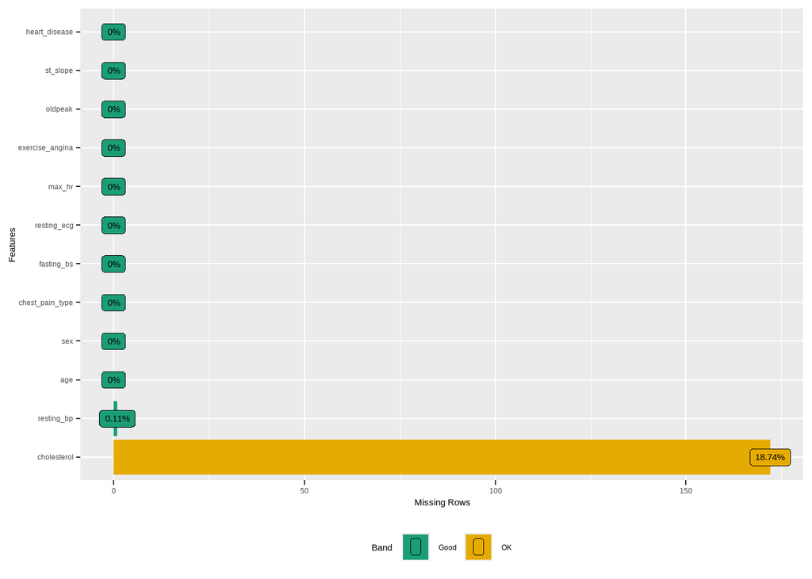

```r
plot_missing(hd_clean)
```

## Data Issues and Outline of proposed Handling Techniques.

### Another data issue is that female participants are underrepresented in the dataset (only make up about 23% of the sample). To address this, when making gender-based predictions, we will use proportional values for the sample of female patients rather than directly comparing them against male participants. This ensures that predictions account for the smaller sample size and avoid bias.

# Exploratory Data Analysis

### Q1: How does maximum heart rate vary with age, and does heart disease change that relationship?

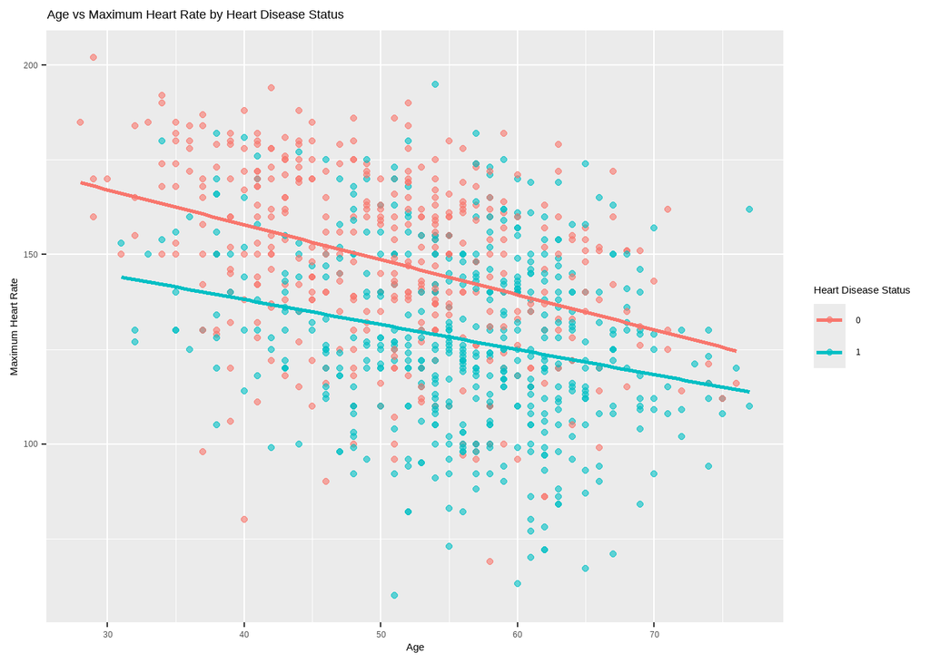

```r
ggplot(hd_clean %>% filter(!is.na(age), !is.na(max_hr)), aes(x = age, y = max_hr, color = heart_disease)) +
  geom_point(alpha = 0.6) +
  geom_smooth(method = "lm", se = FALSE) +
  labs(title = "Age vs Maximum Heart Rate by Heart Disease Status",
       x = "Age",
       y = "Maximum Heart Rate",
       color = "Heart Disease Status")
```

### Q2: Is exercise-induced angina more common among people with heart disease?

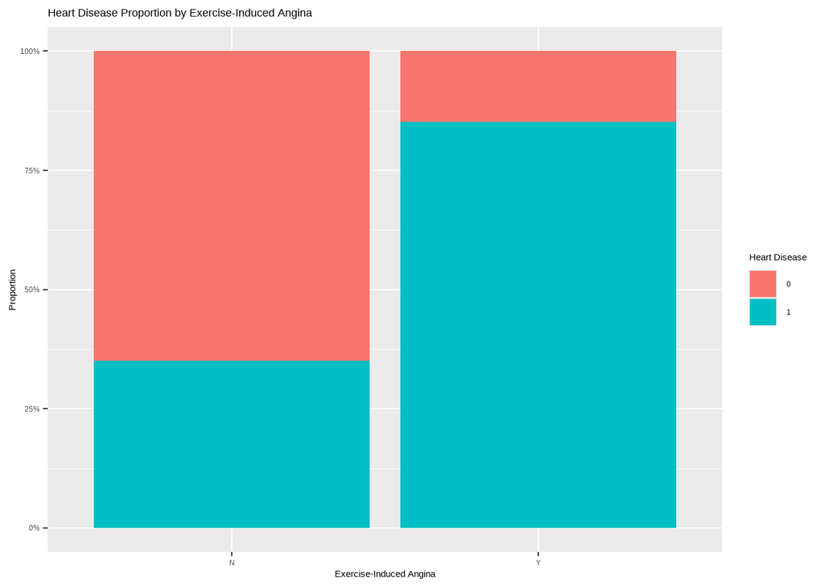

```r
hd_clean %>%
  filter(!is.na(exercise_angina), !is.na(heart_disease)) %>%
  ggplot(aes(x = exercise_angina, fill = factor(heart_disease))) +
  geom_bar(position = "fill") +
  scale_y_continuous(labels = function(x) paste0(round(x * 100), "%")) +
  labs(title = "Heart Disease Proportion by Exercise-Induced Angina",
    x = "Exercise-Induced Angina",y = "Proportion", fill = "Heart Disease")
```

# Interpreter: Landy Brutus

### Q1: Which Chest pain type is most likely to indicate Heart Disease?

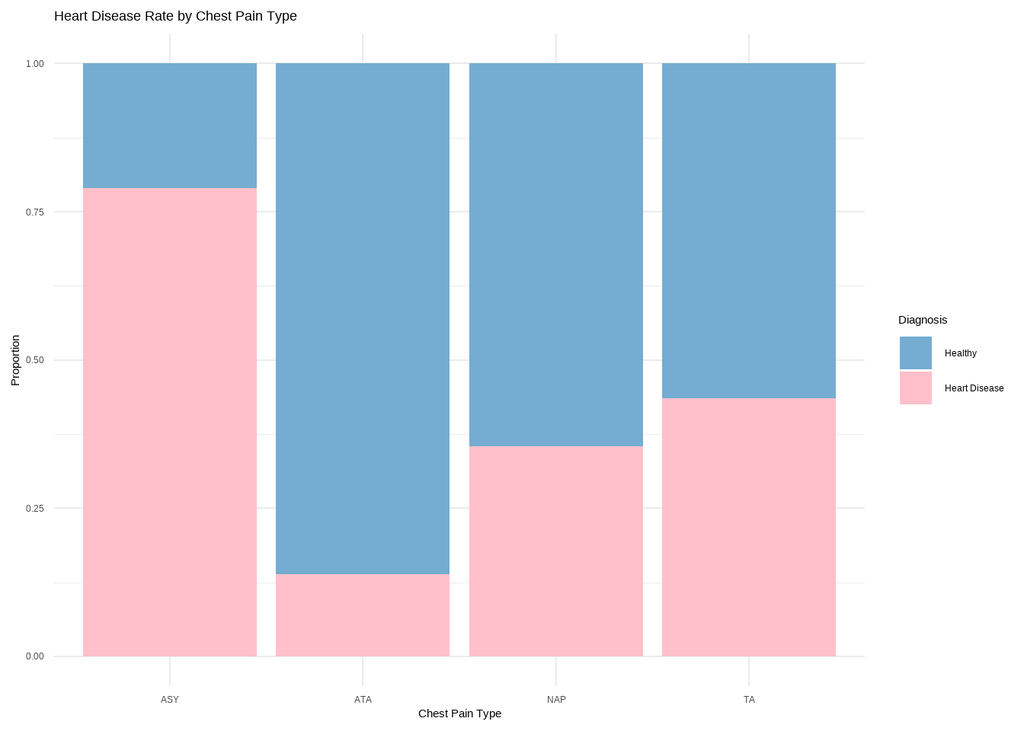

```r
ggplot(hd_clean, aes(x = chest_pain_type, fill = heart_disease)) +
  geom_bar(position = "fill") +
  scale_fill_manual(values = c("0" = "#74add1", "1" = "pink"),
                    labels = c("Healthy", "Heart Disease")) +
  labs(title = "Heart Disease Rate by Chest Pain Type",
       x = "Chest Pain Type",
       y = "Proportion",
       fill = "Diagnosis") +
  theme_minimal()
```

### Q2: Does Resting Blood Pressure (RestingBP) actually increase the risk of heart disease in this group?

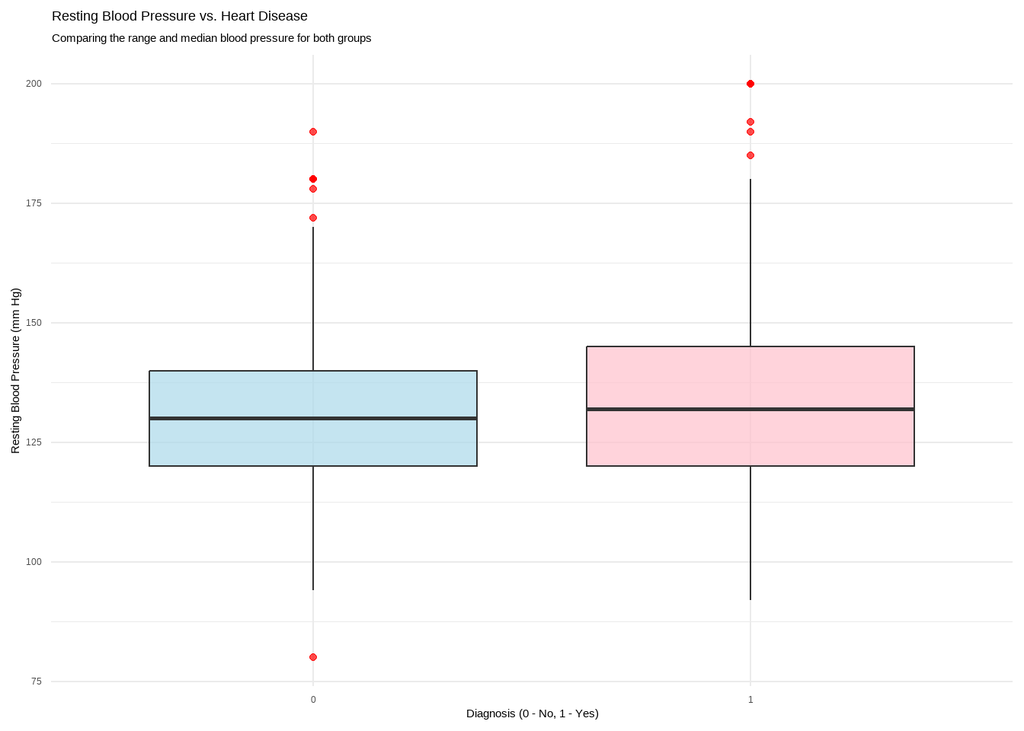

```r
ggplot(hd_clean, aes(x = heart_disease, y = resting_bp, fill = heart_disease)) +
  geom_boxplot(alpha = 0.7, outlier.colour = "red") +
  scale_fill_manual(values = c("0" = "#abd9e9", "1" = "pink"),
                    labels = c("Healthy", "Heart Disease")) +
  labs(title = "Resting Blood Pressure vs. Heart Disease",
       subtitle = "Comparing the range and median blood pressure for both groups",
       x = "Diagnosis (0 - No, 1 - Yes)",
       y = "Resting Blood Pressure (mm Hg)") +
  theme_minimal() +
  theme(legend.position = "none")
```

### Q1: How does the distribution of maximum heart rate vary between patients with and without heart disease?

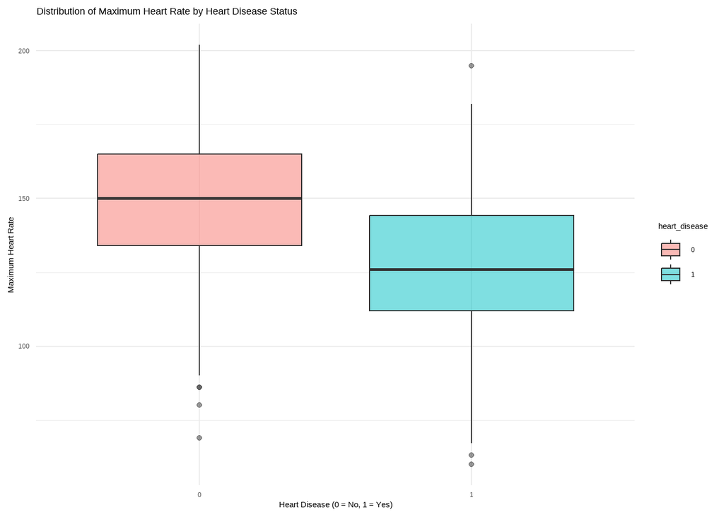

```r
ggplot(hd_clean, aes(x = heart_disease, y = max_hr, fill = heart_disease)) +
  geom_boxplot(alpha = 0.5) +
  labs(
    title = "Distribution of Maximum Heart Rate by Heart Disease Status",
    x = "Heart Disease (0 = No, 1 = Yes)",
    y = "Maximum Heart Rate"
  ) +
  theme_minimal()
```

### Q2: How does the distribution of ST depression differ between patients with and without heart disease?

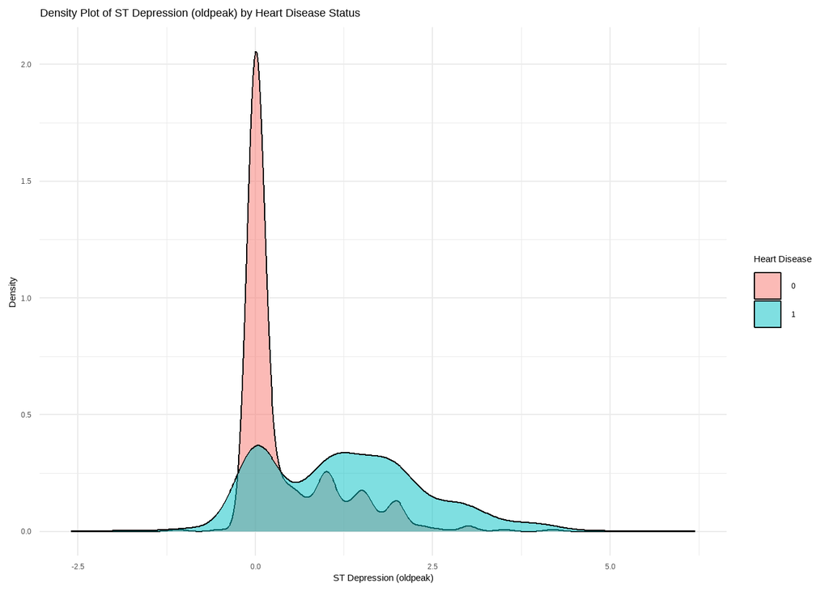

```r
ggplot(hd_clean, aes(x = oldpeak, fill = heart_disease)) +
  geom_density(alpha = 0.5) +
  labs(
    title = "Density Plot of ST Depression (oldpeak) by Heart Disease Status",
    x = "ST Depression (oldpeak)",
    y = "Density",
    fill = "Heart Disease"
  ) +
  theme_minimal()
```

### Q1: What is the correlation between heart diease and Gender?

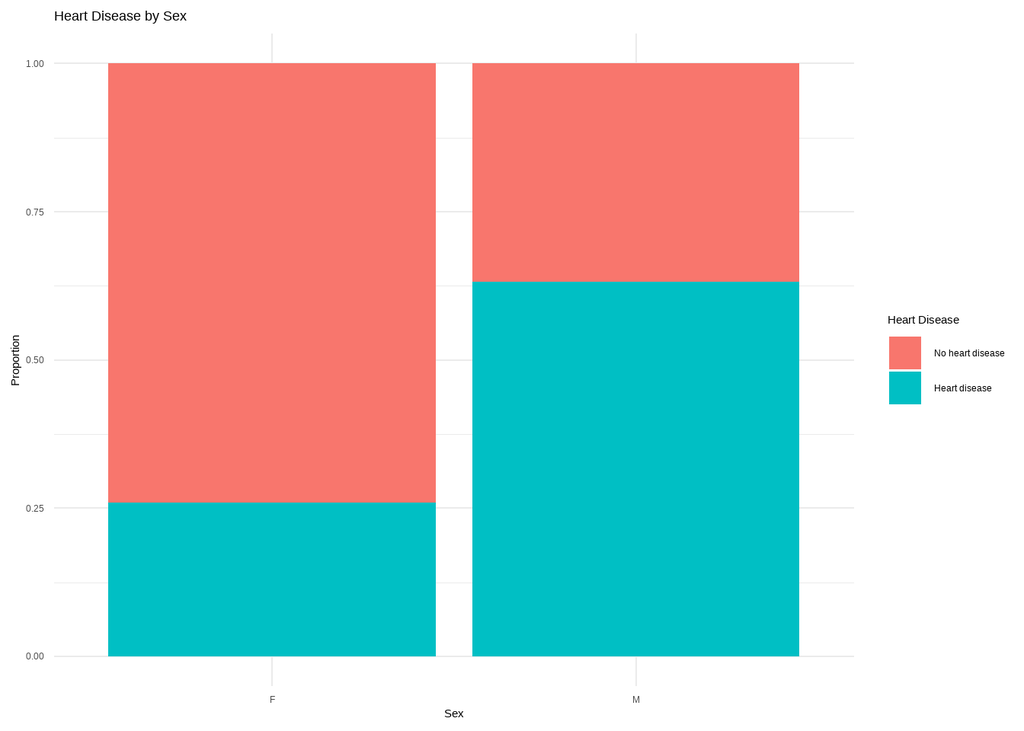

```r
ggplot(hd_clean, aes(x = sex, fill = factor(heart_disease,
      levels = c(0, 1), labels = c("No heart disease", "Heart disease")))) +
  geom_bar(position = "fill") +labs(title = "Heart Disease by Sex",
       x = "Sex", y = "Proportion", fill = "Heart Disease") +
  theme_minimal()
```

### Q2: How do age patterns differ by sex among patients with and without heart disease?

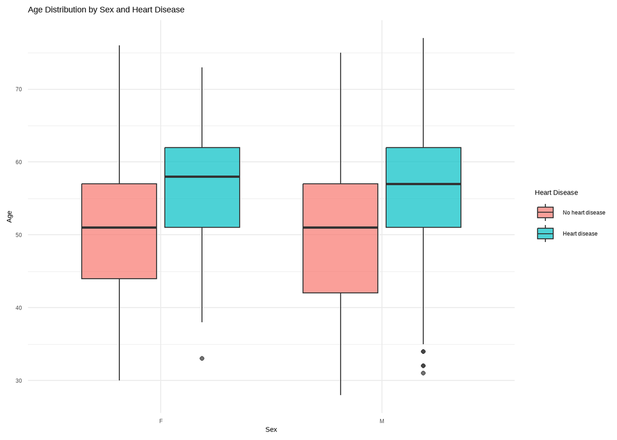

```r
ggplot(hd_clean, aes(x = sex, y = age, fill = factor(heart_disease,
    levels = c(0,1), labels = c("No heart disease", "Heart disease")))) +
  geom_boxplot(alpha = 0.7) + labs(title = "Age Distribution by Sex and Heart Disease",
       x = "Sex", y = "Age", fill = "Heart Disease") +
  theme_minimal()
```

# Follow-up Questions

### New Questions Based Off Initial Investigation

- Q1: Which quantitative variable, when considered alongside age or sex, is most strongly associated with heart disease?
- Q2: How do cholesterol and resting blood pressure interact to influence the probability of heart disease across male and female patients?
- Q3: To what extent do ST depression (oldpeak) and ST slope (st_slope) jointly predict heart disease, and does this association change with age?
- Q4: Do older patients show stronger associations between cholesterol levels and heart disease compared to younger patients?

### Investigation of Follow-up Questions

I decided to investigate Q1 and Q2 in further detail

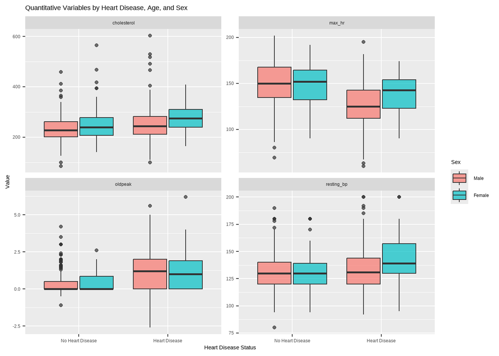

```r
hd_clean |>  # Q1
  select(age, sex, cholesterol, resting_bp, max_hr, oldpeak, heart_disease) |>
  filter(!is.na(age), !is.na(sex), !is.na(heart_disease)) |>
  mutate(heart_disease = factor(heart_disease, levels = c(0, 1),
                           labels = c("No Heart Disease", "Heart Disease")),
    sex = factor(sex, levels = c("M", "F"), labels = c("Male", "Female"))) |>
  pivot_longer(cols = -c(heart_disease, sex, age), names_to = "variable", values_to = "value") |>
  ggplot(aes(x = heart_disease, y = value, fill = sex)) +
  geom_boxplot(position = position_dodge(width = 0.8), alpha = 0.7) +
  facet_wrap(~variable, scales = "free_y") +
  labs(title = "Quantitative Variables by Heart Disease, Age, and Sex",
    x = "Heart Disease Status", y = "Value", fill = "Sex")
```

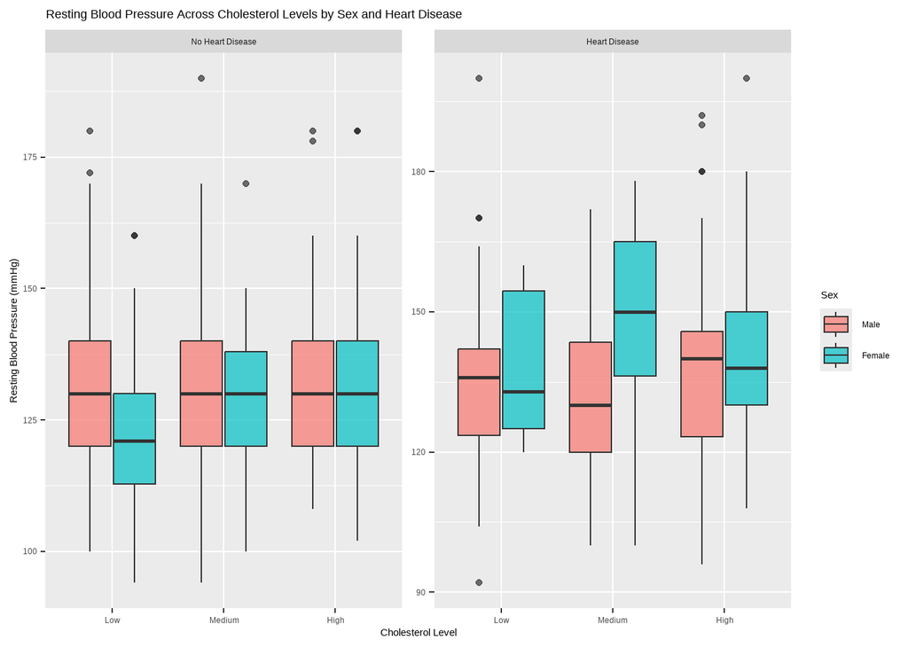

```r
hd_clean |>
  select(sex, cholesterol, resting_bp, heart_disease) |>
  filter(!is.na(cholesterol), !is.na(resting_bp), !is.na(sex), !is.na(heart_disease)) |>
  mutate(heart_disease = factor(heart_disease, levels = c(0, 1),
                           labels = c("No Heart Disease", "Heart Disease")),
    sex = factor(sex, levels = c("M", "F"), labels = c("Male", "Female")),
    cholesterol_level = ntile(cholesterol, 3),
    cholesterol_level = factor(cholesterol_level, labels = c("Low", "Medium", "High"))
  ) |>
  ggplot(aes(x = cholesterol_level, y = resting_bp, fill = sex)) +
  geom_boxplot(position = position_dodge(width = 0.8), alpha = 0.7) +
  facet_wrap(~heart_disease, scales = "free_y") +
  labs(
    title = "Resting Blood Pressure Across Cholesterol Levels by Sex and Heart Disease",
    x = "Cholesterol Level",y = "Resting Blood Pressure (mmHg)", fill = "Sex")
```

# Summary

My initial investigation into individual medical metrics revealed some critical “red flags” for heart disease. One of the most surprising findings that I found was that patients categorized with Asymptomatic chest pain actually had the highest proportion of heart disease. This suggests that the absence of typical pain does not equate to a healthy heart. In addition, our analysis of ST Depression (Oldpeak) showed a large shift in distribution. Whereas, the healthy patients clustered at a value of 0.0, those with heart disease were spread across higher values, making it one of our most clear predictors. I also found that variables like Resting Blood Pressure and Cholesterol showed significant overlap between the two groups when viewed alone. I would say this is eye opening for our group. This is because it led us to realize that these metrics cannot be viewed in isolation. These initial findings directly prompted our follow-up questions about how these variables interact with age and sex to create a more complex risk profile.